# Fraud in clinical trials

```python
import numpy as np
import pandas as pd
import seaborn as sns
import matplotlib.pyplot as plt

sns.set_theme(style="whitegrid")
plt.rcParams["figure.dpi"] = 120
```

```python
URL = "https://raw.githubusercontent.com/VIS-SIG/Wonderful-Wednesdays/master/data/2026/2026-05-13/ADVS.csv"

df = pd.read_csv(URL)
df.head()
```

|  | STUDYID | USUBJID | SUBJID | SITEID | COUNTRY | AGE | SEX | RACE | TRT01P | TRT01PN | ... | AVISITN | PARAMCD | PARAM | AVAL | BASE | CHG | PCHG | ABLFL | ANL01FL | DTYPE |
| --- | --- | --- | --- | --- | --- | --- | --- | --- | --- | --- | --- | --- | --- | --- | --- | --- | --- | --- | --- | --- | --- |
| 0 | BP-RCT-001 | SITE01-001 | 1 | SITE01 | GBR | 70 | M | WHITE | ACTIVE | 1 | ... | 1 | DIABP | Diastolic Blood Pressure (mmHg) | 109 | 109 | NaN | NaN | Y | Y | NaN |
| 1 | BP-RCT-001 | SITE01-001 | 1 | SITE01 | GBR | 70 | M | WHITE | ACTIVE | 1 | ... | 2 | DIABP | Diastolic Blood Pressure (mmHg) | 107 | 109 | -2.0 | -1.834862 | NaN | Y | NaN |
| 2 | BP-RCT-001 | SITE01-001 | 1 | SITE01 | GBR | 70 | M | WHITE | ACTIVE | 1 | ... | 3 | DIABP | Diastolic Blood Pressure (mmHg) | 108 | 109 | -1.0 | -0.917431 | NaN | Y | NaN |
| 3 | BP-RCT-001 | SITE01-001 | 1 | SITE01 | GBR | 70 | M | WHITE | ACTIVE | 1 | ... | 4 | DIABP | Diastolic Blood Pressure (mmHg) | 104 | 109 | -5.0 | -4.587156 | NaN | Y | NaN |
| 4 | BP-RCT-001 | SITE01-001 | 1 | SITE01 | GBR | 70 | M | WHITE | ACTIVE | 1 | ... | 5 | DIABP | Diastolic Blood Pressure (mmHg) | 102 | 109 | -7.0 | -6.422018 | NaN | Y | NaN |

5 rows × 30 columns

```python
# Clean data
df["AVAL"] = pd.to_numeric(df["AVAL"], errors="coerce")
df["CHG"] = pd.to_numeric(df["CHG"], errors="coerce")
df["AVISITN"] = pd.to_numeric(df["AVISITN"], errors="coerce")
df["ADT"] = pd.to_datetime(df["ADT"], dayfirst=True, errors="coerce")

# Basic check
print(df.shape)
print(df["SITEID"].value_counts())
print(df.head())
```

```
(2320, 30)
SITEID
SITE03    420
SITE06    400
SITE04    394
SITE02    382
SITE05    374
SITE01    350
Name: count, dtype: int64
      STUDYID     USUBJID  SUBJID  SITEID COUNTRY  AGE SEX   RACE  TRT01P  \
0  BP-RCT-001  SITE01-001       1  SITE01     GBR   70   M  WHITE  ACTIVE
1  BP-RCT-001  SITE01-001       1  SITE01     GBR   70   M  WHITE  ACTIVE
2  BP-RCT-001  SITE01-001       1  SITE01     GBR   70   M  WHITE  ACTIVE
3  BP-RCT-001  SITE01-001       1  SITE01     GBR   70   M  WHITE  ACTIVE
4  BP-RCT-001  SITE01-001       1  SITE01     GBR   70   M  WHITE  ACTIVE

   TRT01PN  ... AVISITN  PARAMCD                            PARAM AVAL BASE  \
0        1  ...       1    DIABP  Diastolic Blood Pressure (mmHg)  109  109
1        1  ...       2    DIABP  Diastolic Blood Pressure (mmHg)  107  109
2        1  ...       3    DIABP  Diastolic Blood Pressure (mmHg)  108  109
3        1  ...       4    DIABP  Diastolic Blood Pressure (mmHg)  104  109
4        1  ...       5    DIABP  Diastolic Blood Pressure (mmHg)  102  109

   CHG      PCHG ABLFL  ANL01FL DTYPE
0  NaN       NaN     Y        Y   NaN
1 -2.0 -1.834862   NaN        Y   NaN
2 -1.0 -0.917431   NaN        Y   NaN
3 -5.0 -4.587156   NaN        Y   NaN
4 -7.0 -6.422018   NaN        Y   NaN

[5 rows x 30 columns]
```

# 1. Digit preference: round numbers

```
   SITEID  proportion_round_0_or_5
0  SITE01                 0.242857
1  SITE02                 0.222513
2  SITE03                 0.821429
3  SITE04                 0.187817
4  SITE05                 0.181818
5  SITE06                 0.185000
```

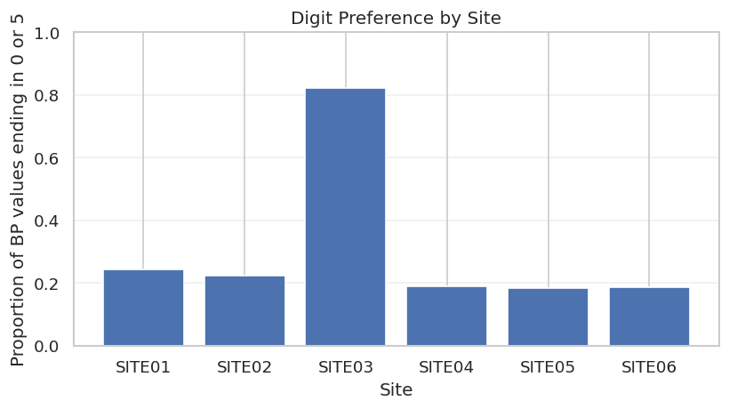

```python
df["last_digit"] = df["AVAL"].astype(int).abs() % 10
df["round_0_5"] = df["last_digit"].isin([0, 5])

digit_pref = (
    df.groupby("SITEID")["round_0_5"]
    .mean()
    .reset_index(name="proportion_round_0_or_5")
)

print(digit_pref)

plt.figure(figsize=(7,4))
plt.bar(digit_pref["SITEID"], digit_pref["proportion_round_0_or_5"])
plt.title("Digit Preference by Site")
plt.xlabel("Site")
plt.ylabel("Proportion of BP values ending in 0 or 5")
plt.ylim(0, 1)
plt.grid(axis="y", alpha=0.3)
plt.tight_layout()
plt.show()
```

if one site has many more values ending in 0 or 5, that suggests possible fabricated or rounded measurements.

# 2. Last digit distribution by site

```
last_digit         0         1         2         3         4         5  \
SITEID
SITE01      0.111429  0.091429  0.117143  0.077143  0.088571  0.131429
SITE02      0.107330  0.070681  0.115183  0.091623  0.117801  0.115183
SITE03      0.295238  0.023810  0.023810  0.033333  0.033333  0.526190
SITE04      0.098985  0.109137  0.106599  0.076142  0.081218  0.088832
SITE05      0.077540  0.101604  0.088235  0.098930  0.122995  0.104278
SITE06      0.087500  0.090000  0.087500  0.085000  0.117500  0.097500

last_digit         6         7         8         9
SITEID
SITE01      0.091429  0.102857  0.100000  0.088571
SITE02      0.091623  0.086387  0.102094  0.102094
SITE03      0.026190  0.011905  0.011905  0.014286
SITE04      0.101523  0.126904  0.126904  0.083756
SITE05      0.101604  0.106952  0.122995  0.074866
SITE06      0.102500  0.120000  0.115000  0.097500
```

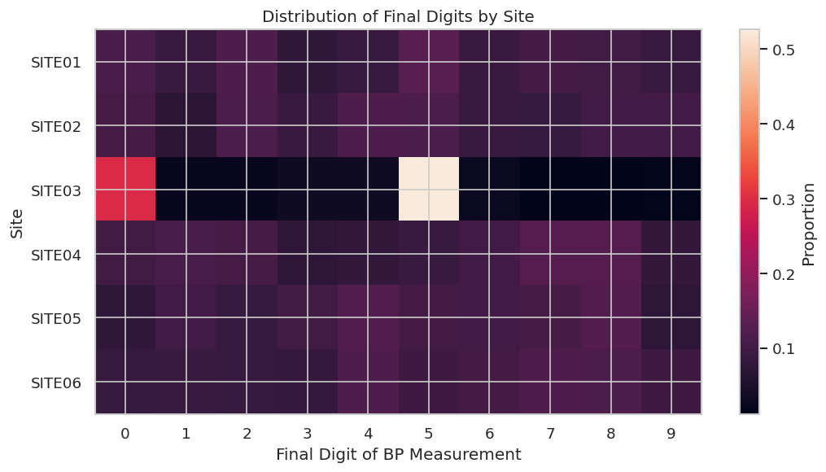

```python
digit_table = pd.crosstab(df["SITEID"], df["last_digit"], normalize="index")

print(digit_table)

plt.figure(figsize=(9,5))
plt.imshow(digit_table, aspect="auto")
plt.colorbar(label="Proportion")
plt.xticks(range(10), range(10))
plt.yticks(range(len(digit_table.index)), digit_table.index)
plt.title("Distribution of Final Digits by Site")
plt.xlabel("Final Digit of BP Measurement")
plt.ylabel("Site")
plt.tight_layout()
plt.show()
```

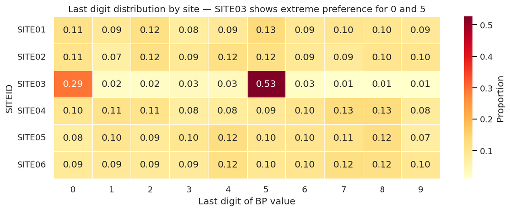

```python
digit_table = pd.crosstab(df["SITEID"], df["last_digit"], normalize="index").round(3)

plt.figure(figsize=(10, 4))
sns.heatmap(digit_table, annot=True, fmt=".2f", cmap="YlOrRd",
            linewidths=0.5, cbar_kws={"label": "Proportion"})
plt.title("Last digit distribution by site — SITE03 shows extreme preference for 0 and 5")
plt.xlabel("Last digit of BP value")
plt.tight_layout()
plt.show()
```

Story: real measurements should have a fairly mixed digit pattern. SITE03 should appear unusual here.

# 3. Variability: fake data is often too consistent

```
    SITEID PARAMCD  sd_change
0   SITE01   DIABP   4.962773
1   SITE01   SYSBP   7.369588
2   SITE02   DIABP   5.630034
3   SITE02   SYSBP   9.200822
4   SITE03   DIABP   3.327271
5   SITE03   SYSBP   5.223485
6   SITE04   DIABP   5.778665
7   SITE04   SYSBP   8.947973
8   SITE05   DIABP   6.394070
9   SITE05   SYSBP   7.268345
10  SITE06   DIABP   5.131955
11  SITE06   SYSBP   7.276693
```

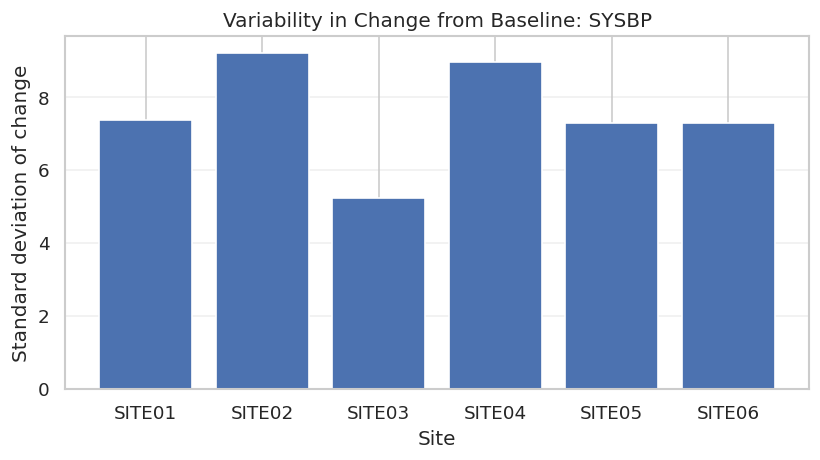

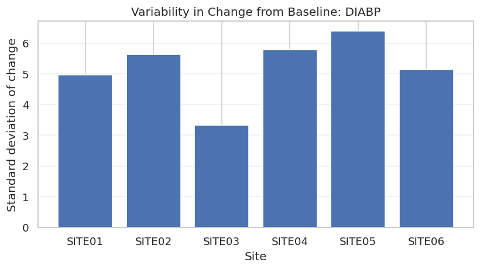

```python
post_base = df[df["AVISITN"] > 1]

variability = (
    post_base.groupby(["SITEID", "PARAMCD"])["CHG"]
    .std()
    .reset_index(name="sd_change")
)

print(variability)

for param in ["SYSBP", "DIABP"]:
    temp = variability[variability["PARAMCD"] == param]

    plt.figure(figsize=(7,4))
    plt.bar(temp["SITEID"], temp["sd_change"])
    plt.title(f"Variability in Change from Baseline: {param}")
    plt.xlabel("Site")
    plt.ylabel("Standard deviation of change")
    plt.grid(axis="y", alpha=0.3)
    plt.tight_layout()
    plt.show()
```

Story: suspicious fabricated data often has lower variability than real patient data.

# 4. Missing data / dropout

```
   SITEID  mean_visits  full_completion
0  SITE01     5.833333         0.666667
1  SITE02     6.366667         0.766667
2  SITE03     7.000000         1.000000
3  SITE04     6.566667         0.700000
4  SITE05     6.233333         0.700000
5  SITE06     6.666667         0.833333
```

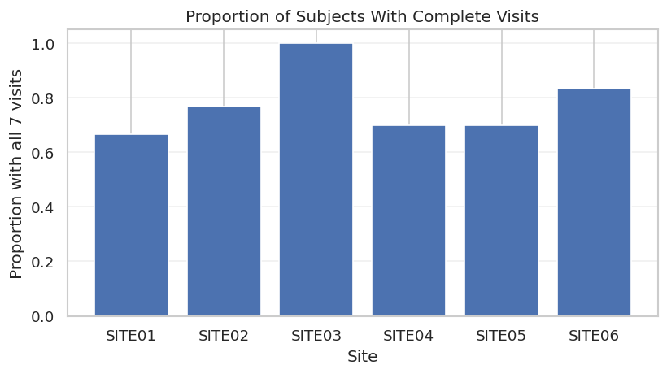

```python
visits = (
    df.drop_duplicates(["SITEID", "USUBJID", "AVISITN", "ADT"])
    .sort_values(["SITEID", "USUBJID", "AVISITN"])
)

visits_per_subject = (
    visits.groupby(["SITEID", "USUBJID"])["AVISITN"]
    .nunique()
    .reset_index(name="n_visits")
)

completion = (
    visits_per_subject.groupby("SITEID")
    .agg(
        mean_visits=("n_visits", "mean"),
        full_completion=("n_visits", lambda x: (x == 7).mean())
    )
    .reset_index()
)

print(completion)

plt.figure(figsize=(7,4))
plt.bar(completion["SITEID"], completion["full_completion"])
plt.title("Proportion of Subjects With Complete Visits")
plt.xlabel("Site")
plt.ylabel("Proportion with all 7 visits")
plt.ylim(0, 1.05)
plt.grid(axis="y", alpha=0.3)
plt.tight_layout()
plt.show()
```

SITE03 having every subject complete all visits would be suspicious because real trials usually have missed visits/dropouts.

# 5. Visit regularity

```
   SITEID       mean       std   min   max
0  SITE01  28.124138  2.938922  23.0  34.0
1  SITE02  27.987578  2.537192  22.0  34.0
2  SITE03  28.000000  0.000000  28.0  28.0
3  SITE04  27.976048  2.744001  22.0  34.0
4  SITE05  27.834395  3.094344  22.0  34.0
5  SITE06  27.894118  2.782122  22.0  34.0
```

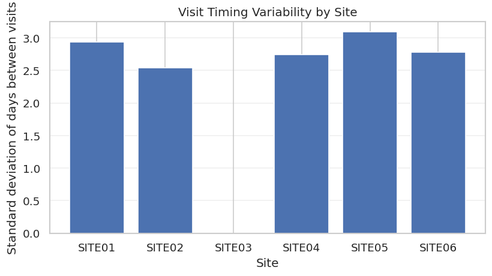

```python
visits["days_between"] = (
    visits.groupby(["SITEID", "USUBJID"])["ADT"]
    .diff()
    .dt.days
)

intervals = visits.dropna(subset=["days_between"])

interval_summary = (
    intervals.groupby("SITEID")["days_between"]
    .agg(["mean", "std", "min", "max"])
    .reset_index()
)

print(interval_summary)

plt.figure(figsize=(7,4))
plt.bar(interval_summary["SITEID"], interval_summary["std"])
plt.title("Visit Timing Variability by Site")
plt.xlabel("Site")
plt.ylabel("Standard deviation of days between visits")
plt.grid(axis="y", alpha=0.3)
plt.tight_layout()
plt.show()
```

Story: in real life, visit intervals vary. If a site has almost zero variation, that is suspicious.

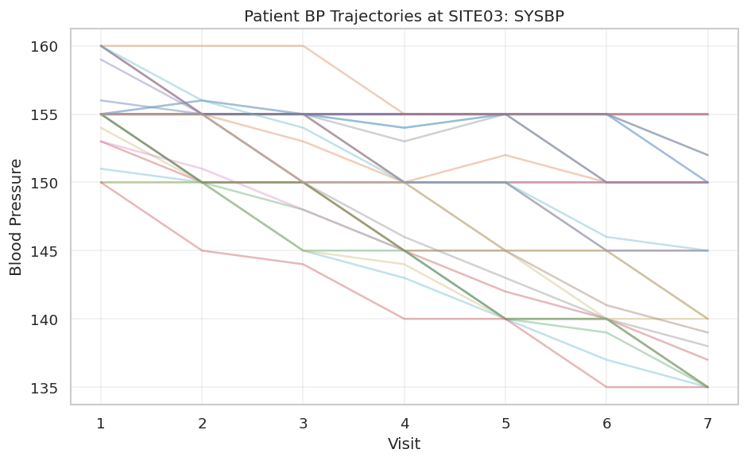

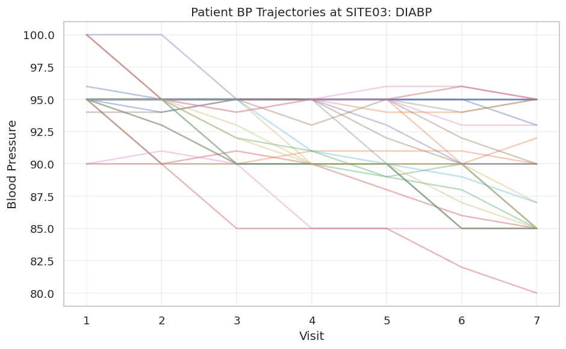

```python
suspect_site = "SITE03"

for param in ["SYSBP", "DIABP"]:
    temp = df[(df["SITEID"] == suspect_site) & (df["PARAMCD"] == param)]

    plt.figure(figsize=(8,5))

    for subject, group in temp.groupby("USUBJID"):
        group = group.sort_values("AVISITN")
        plt.plot(group["AVISITN"], group["AVAL"], alpha=0.4)

    plt.title(f"Patient BP Trajectories at {suspect_site}: {param}")
    plt.xlabel("Visit")
    plt.ylabel("Blood Pressure")
    plt.grid(alpha=0.3)
    plt.tight_layout()
    plt.show()
```

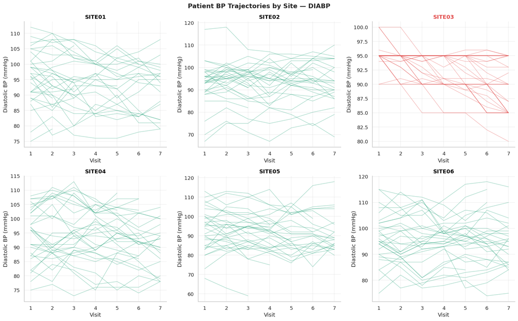

```python
fig, axes = plt.subplots(2, 3, figsize=(16, 10), sharey=False)
fig.suptitle("Patient BP Trajectories by Site — DIABP", fontsize=14, fontweight="bold")

for ax, site in zip(axes.flatten(), sites):
    site_data = df[(df["SITEID"] == site) & (df["PARAMCD"] == "DIABP")]
    for subject, group in site_data.groupby("USUBJID"):
        group = group.sort_values("AVISITN")
        color = "#E24B4A" if site == "SITE03" else "#1D9E75"
        ax.plot(group["AVISITN"], group["AVAL"], alpha=0.4, color=color, linewidth=1)

    ax.set_title(site, fontweight="bold",
                 color="#E24B4A" if site == "SITE03" else "black")
    ax.set_xlabel("Visit")
    ax.set_ylabel("Diastolic BP (mmHg)")
    ax.grid(alpha=0.3)
    ax.spines[["top", "right"]].set_visible(False)

plt.tight_layout()
plt.show()
```

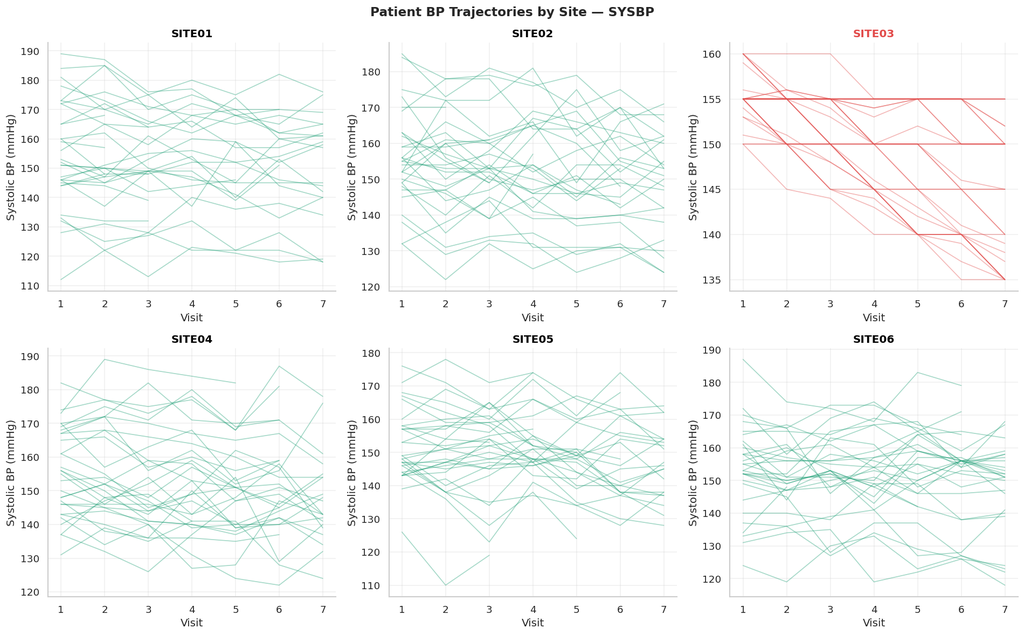

```python
fig, axes = plt.subplots(2, 3, figsize=(16, 10), sharey=False)
fig.suptitle("Patient BP Trajectories by Site — SYSBP", fontsize=14, fontweight="bold")

for ax, site in zip(axes.flatten(), sites):
    site_data = df[(df["SITEID"] == site) & (df["PARAMCD"] == "SYSBP")]
    for subject, group in site_data.groupby("USUBJID"):
        group = group.sort_values("AVISITN")
        color = "#E24B4A" if site == "SITE03" else "#1D9E75"
        ax.plot(group["AVISITN"], group["AVAL"], alpha=0.4, color=color, linewidth=1)

    ax.set_title(site, fontweight="bold",
                 color="#E24B4A" if site == "SITE03" else "black")
    ax.set_xlabel("Visit")
    ax.set_ylabel("Systolic BP (mmHg)")
    ax.grid(alpha=0.3)
    ax.spines[["top", "right"]].set_visible(False)

plt.tight_layout()
plt.show()
```

```python
# Digit preference
digit_pref = (
    df.groupby("SITEID")["round_0_5"]
    .mean()
    .reset_index(name="round_digit_rate")
)

# Variability
site_var = (
    post_base.groupby("SITEID")["CHG"]
    .std()
    .reset_index(name="change_sd")
)

# Completion
completion = completion[["SITEID", "full_completion"]]

# Visit timing variability
interval_sd = interval_summary[["SITEID", "std"]].rename(columns={"std": "visit_interval_sd"})

# Combine
fraud_indicators = (
    digit_pref
    .merge(site_var, on="SITEID")
    .merge(completion, on="SITEID")
    .merge(interval_sd, on="SITEID")
)

print(fraud_indicators)
```

```
   SITEID  round_digit_rate  change_sd  full_completion  visit_interval_sd
0  SITE01          0.242857   6.277419         0.666667           2.938922
1  SITE02          0.222513   7.831257         0.766667           2.537192
2  SITE03          0.821429   4.621213         1.000000           0.000000
3  SITE04          0.187817   7.634920         0.700000           2.744001
4  SITE05          0.181818   6.835951         0.700000           3.094344
5  SITE06          0.185000   6.339367         0.833333           2.782122
```

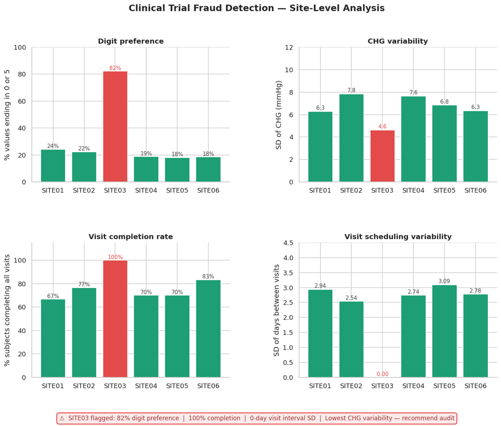

```python
# Map your existing variables to the dashboard
sites = fraud_indicators["SITEID"].tolist()
round_vals  = fraud_indicators.set_index("SITEID")["round_digit_rate"] * 100
sd_vals     = fraud_indicators.set_index("SITEID")["change_sd"]
comp_vals   = fraud_indicators.set_index("SITEID")["full_completion"] * 100
int_vals    = fraud_indicators.set_index("SITEID")["visit_interval_sd"]

fraud_site = "SITE03"
colors = ["#E24B4A" if s == fraud_site else "#1D9E75" for s in sites]

import matplotlib.gridspec as gridspec

fig = plt.figure(figsize=(14, 10), facecolor="white")
fig.suptitle("Clinical Trial Fraud Detection — Site-Level Analysis",
             fontsize=15, fontweight="bold", y=0.98)

gs = gridspec.GridSpec(2, 2, figure=fig, hspace=0.45, wspace=0.35)

# Panel 1: Digit preference
ax1 = fig.add_subplot(gs[0, 0])
ax1.bar(sites, round_vals[sites], color=colors, edgecolor="white")
ax1.set_ylabel("% values ending in 0 or 5")
ax1.set_title("Digit preference", fontweight="bold")
ax1.set_ylim(0, 100)
for i, (s, v) in enumerate(zip(sites, round_vals[sites])):
    ax1.text(i, v + 1, f"{v:.0f}%", ha="center", fontsize=9,
             color="#E24B4A" if s == fraud_site else "#444")
ax1.spines[["top", "right"]].set_visible(False)

# Panel 2: CHG variability
ax2 = fig.add_subplot(gs[0, 1])
ax2.bar(sites, sd_vals[sites], color=colors, edgecolor="white")
ax2.set_ylabel("SD of CHG (mmHg)")
ax2.set_title("CHG variability", fontweight="bold")
ax2.set_ylim(0, 12)
for i, (s, v) in enumerate(zip(sites, sd_vals[sites])):
    ax2.text(i, v + 0.15, f"{v:.1f}", ha="center", fontsize=9,
             color="#E24B4A" if s == fraud_site else "#444")
ax2.spines[["top", "right"]].set_visible(False)

# Panel 3: Completion rate
ax3 = fig.add_subplot(gs[1, 0])
ax3.bar(sites, comp_vals[sites], color=colors, edgecolor="white")
ax3.set_ylabel("% subjects completing all visits")
ax3.set_title("Visit completion rate", fontweight="bold")
ax3.set_ylim(0, 115)
for i, (s, v) in enumerate(zip(sites, comp_vals[sites])):
    ax3.text(i, v + 1, f"{v:.0f}%", ha="center", fontsize=9,
             color="#E24B4A" if s == fraud_site else "#444")
ax3.spines[["top", "right"]].set_visible(False)

# Panel 4: Visit interval SD
ax4 = fig.add_subplot(gs[1, 1])
ax4.bar(sites, int_vals[sites], color=colors, edgecolor="white")
ax4.set_ylabel("SD of days between visits")
ax4.set_title("Visit scheduling variability", fontweight="bold")
ax4.set_ylim(0, 4.5)
for i, (s, v) in enumerate(zip(sites, int_vals[sites])):
    ax4.text(i, v + 0.05, f"{v:.2f}", ha="center", fontsize=9,
             color="#E24B4A" if s == fraud_site else "#444")
ax4.spines[["top", "right"]].set_visible(False)

# Verdict banner
fig.text(0.5, 0.01,
    "⚠  SITE03 flagged: 82% digit preference  |  100% completion  |  "
    "0-day visit interval SD  |  Lowest CHG variability — recommend audit",
    ha="center", fontsize=10, color="#A32D2D",
    bbox=dict(boxstyle="round,pad=0.4", facecolor="#FCEBEB",
              edgecolor="#E24B4A", linewidth=1.5))

plt.savefig("fraud_detection.png", dpi=150, bbox_inches="tight")
plt.show()
```

## Summary dashboard

Four independent statistical indicators are examined across all six sites. SITE03 (red) is a clear outlier on every measure simultaneously.

## Overall suspicion score

Each indicator is standardised to a z-score (mean = 0, SD = 1) so they can be combined on the same scale. Positive = more suspicious than average, negative = less suspicious. The four z-scores are summed into one composite score. No legitimate site fails all four checks — SITE03 does.

```
   SITEID  round_digit_rate  change_sd  full_completion  visit_interval_sd  \
2  SITE03          0.821429   4.621213         1.000000           0.000000
5  SITE06          0.185000   6.339367         0.833333           2.782122
0  SITE01          0.242857   6.277419         0.666667           2.938922
1  SITE02          0.222513   7.831257         0.766667           2.537192
4  SITE05          0.181818   6.835951         0.700000           3.094344
3  SITE04          0.187817   7.634920         0.700000           2.744001

   overall_suspicion_score
2                 7.533657
5                -0.188782
0                -1.384082
1                -1.653663
4                -1.971274
3                -2.335856
```

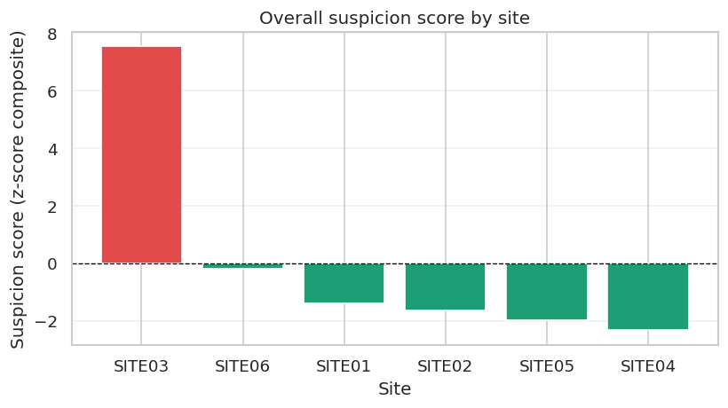

```python
score = fraud_indicators.copy()

# Higher round_digit_rate = more suspicious
score["round_score"] = (
    (score["round_digit_rate"] - score["round_digit_rate"].mean())
    / score["round_digit_rate"].std()
)

# Lower variability = more suspicious
score["low_variability_score"] = (
    (score["change_sd"].mean() - score["change_sd"])
    / score["change_sd"].std()
)

# Higher completion = more suspicious
score["completion_score"] = (
    (score["full_completion"] - score["full_completion"].mean())
    / score["full_completion"].std()
)

# Lower visit interval SD = more suspicious
score["regular_visit_score"] = (
    (score["visit_interval_sd"].mean() - score["visit_interval_sd"])
    / score["visit_interval_sd"].std()
)

score["overall_suspicion_score"] = (
    score["round_score"]
    + score["low_variability_score"]
    + score["completion_score"]
    + score["regular_visit_score"]
)

score = score.sort_values("overall_suspicion_score", ascending=False)

print(score[[
    "SITEID",
    "round_digit_rate",
    "change_sd",
    "full_completion",
    "visit_interval_sd",
    "overall_suspicion_score"
]])


bar_colors = ['#E24B4A' if s == 'SITE03' else '#1D9E75'
              for s in score["SITEID"]]

plt.figure(figsize=(7, 4))
plt.bar(score["SITEID"], score["overall_suspicion_score"], color=bar_colors)
plt.title("Overall suspicion score by site")
plt.xlabel("Site")
plt.ylabel("Suspicion score (z-score composite)")
plt.axhline(0, color='black', linewidth=0.8, linestyle='--')
plt.grid(axis="y", alpha=0.3)
plt.tight_layout()
plt.show()
```

## Conclusion

SITE03 is flagged as the suspected fraudulent site based on four independent indicators:

- **82%** of BP values end in 0 or 5 (vs ~19% at all other sites)
- **0% dropout** — all 30 subjects completed all 7 visits (implausible in a real trial)
- **Visit interval SD = 0** — every visit on the exact scheduled day (impossible at scale)
- **Lowest CHG variability** (SD = 4.6 vs 6.3–7.8 elsewhere)

No legitimate site fails all four checks simultaneously. Recommend audit of SITE03.

# Create HTML

```python
from google.colab import drive
drive.mount('/content/drive')
```

```python
path = "/content/drive/MyDrive/Colab Notebooks/Fraud in clinical trials.ipynb"
!jupyter nbconvert --to html --embed-images "{path}"

html_path = path.replace(".ipynb", ".html")
from google.colab import files
files.download(html_path)
```

```
[NbConvertApp] Converting notebook /content/drive/MyDrive/Colab Notebooks/Fraud in clinical trials.ipynb to html
[NbConvertApp] WARNING | Alternative text is missing on 13 image(s).
[NbConvertApp] Writing 2986897 bytes to /content/drive/MyDrive/Colab Notebooks/Fraud in clinical trials.html
```